# Exploring gapminder: Solution to final challenge

Naupaka Zimmerman

April 19, 2015

### Scatter plots

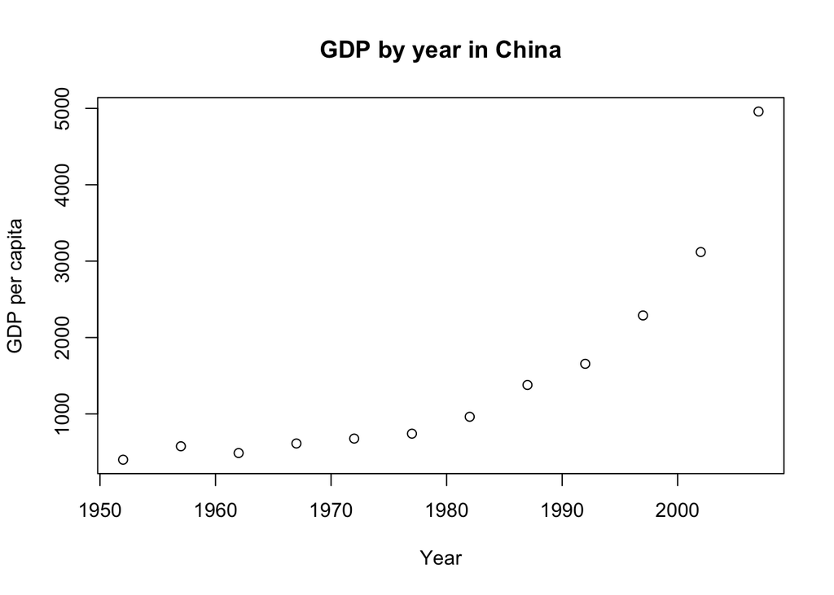

We see a huge increase in per capita GDP in China starting in the 1990s.

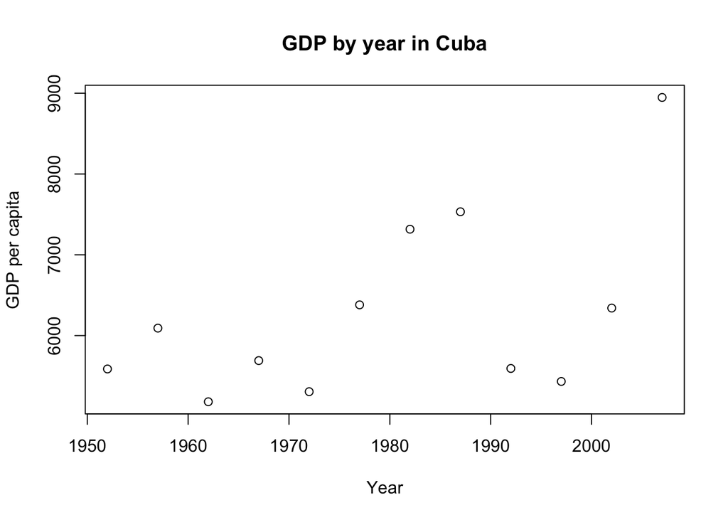

In Cuba, GDP reaches a peak in the 1980s, before becoming much lower in the 1990s, and climbing again after the year 2000.

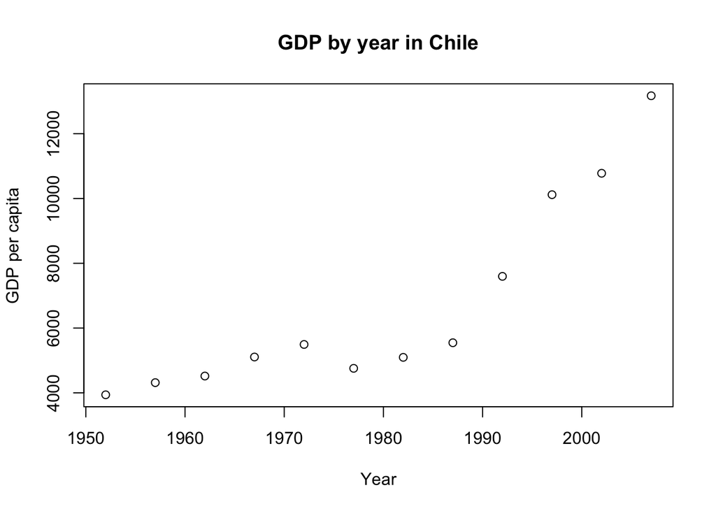

### Summary statistics

Life expectancies per continent

| continent | mean | min | max |
| --- | --- | --- | --- |
| Africa | 48.86533 | 23.599 | 76.442 |
| Americas | 64.65874 | 37.579 | 80.653 |
| Asia | 60.06490 | 28.801 | 82.603 |
| Europe | 71.90369 | 43.585 | 81.757 |
| Oceania | 74.32621 | 69.120 | 81.235 |

Mean life expectancies (MLE) over this period are highest in Oceania, where MLE is 74.33. They are lowest in Africa (mean 48.87). While maximum life expectancies are relatively similar across continents, minimum life expectancies vary dramtically, and the lowest values are from Africa (23.6) and Asia (28.8).

### Histograms of global life expectancy

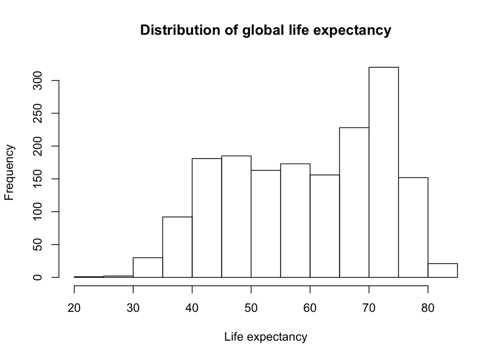

We see a peak in life expectancy around 70 years of age, although it also seems that the distribution is non-normal.

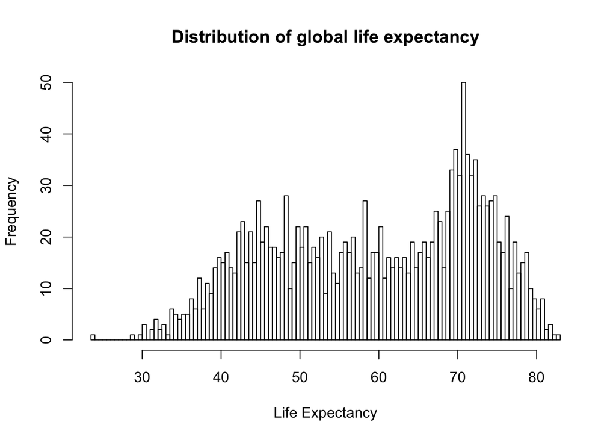

The non-normality is even more evident with more bins, and there is even a hint that it might be bi-modal, with a second (less frequent) peak near 45 years of age.